# Final Report

Nathaniel, Alex, Cesar, Liam

2022-12-08

## Question and Data

During the COVID pandemic, the Centers for Disease and Control and Prevention (CDC) published an article showing that the obese population was more likely to die or have further complications due to the virus. There are countless other similar studies that indicate the severity of the health problem that is obesity.

The United States is the most relevant country in the world, being known for being a land of great opportunity, wealth and freedom. However, along with that, there is an immediate association of the country with a sedentary life style, fast food restaurants and obesity. The stereotype doesn’t come from nowhere: The United States has an obesity rate of 36.5%, making the country the most obese among developed countries. Within the limits of the conclusions that the field of data science can make, we decided to answer: Is the availability to fast food restaurants in the USA associated with higher obesity rates? We will also attempt to discover other variables that could be associated with obesity rates and determine how correlated they seem to be with obesity rates. Or rather, which factors are the best predictors of obesity rate?

## Data

We used data from the Food Environment Atlas by the U.S Department of Agriculture collected in years ranging from 2013 to 2015. They use as their sources the BRFSS, the U.S. Census, and the USDA’s Economic Research Service as their sources and they organize their data at the county level - therefore we have used each county as one data point. We believe that the fact the data is from different years may cause a slight alteration in the results of our model. This should be negligible since they’re only at most two years apart.

We picked a few variables that we thought could be relevant in determining obesity rates:

obesrate = rate of obesity in each county in the US, 2013 fasfoo = fast-food restaurants per 1000 people in each county in the US, 2014 medinc = median household income, 2015 diab = rate of diabetes in each county in the US, 2013 fitplace = recreation & fitness facilities per 1000 people in each county in the US, 2014 loaccgro = percent of access to grocery stores in each county in the US, 2015.

https://www.ers.usda.gov/data-products/food-environment-atlas/data-access-and-documentation-downloads/

## Methods

To answer our question, we chose to use a two step process. For the first step, we decided to split the initial data set by clustering using k-means. This would allow our models in the second step of the process to make better predictions. Plus, separating our data to create different models will prevent over-fitting. Clustering may also offer additional insights in our data. For example, we can use visualizations to identify new patterns by location.

We clustered on the variables mentioned above (fasfoo, medinc, diab, fitplace, loaccgro), excluding obesity rate as this is our target variable.

Based on the elbow the elbow chart below, 4 centers looked the best for k-means. For each of the 4 clusters, we created 4 new data sets, leading us to the second step of our two-step process. For each data set, we trained a random forest regression model, evaluating them using mean-squared error (MSE).

We decided to use decision trees because they allow us to determine which features are most useful in predicting our target variable, helping us answer our question above of which features are the best predictors of obesity rate. Furthermore, we used random forests to mitigate under-predicting and over-predicting through their use of bagging and boosting.

## Exploratory Data Analysis

Since we use a two step data analysis process, first clustering the data and then running separate models in each cluster, we thought this would be a good opportunity to explore these clusters a little more.

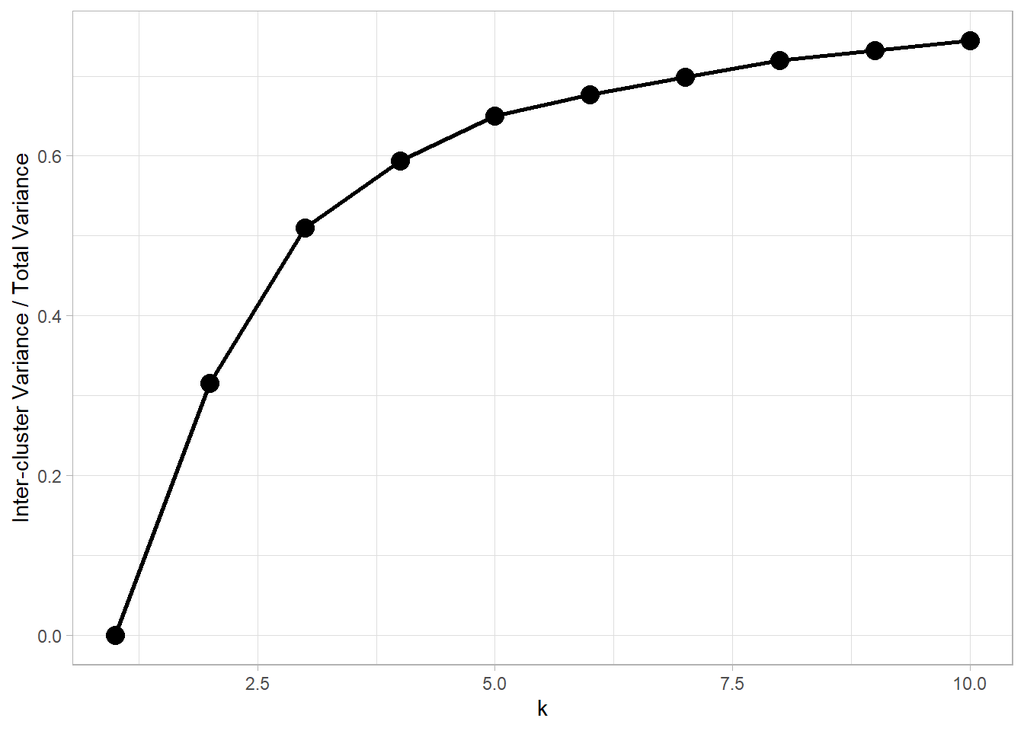

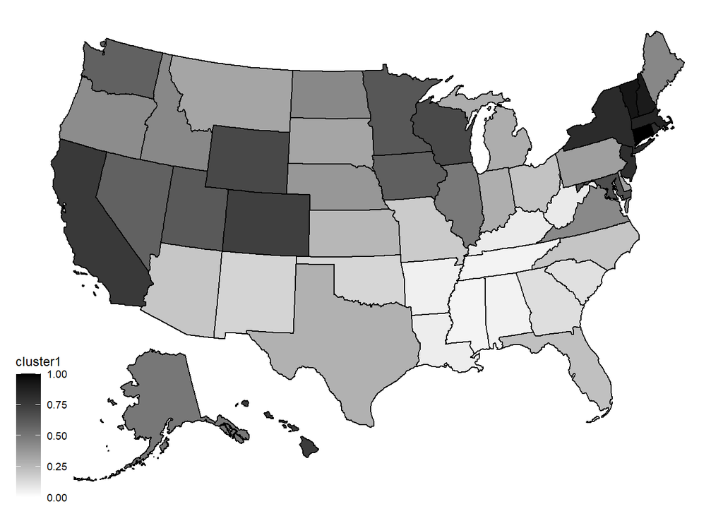

Cluster 1: Clustered the wealthier counties, with lower diabetes rates highest proportions of access to fitness establishments.

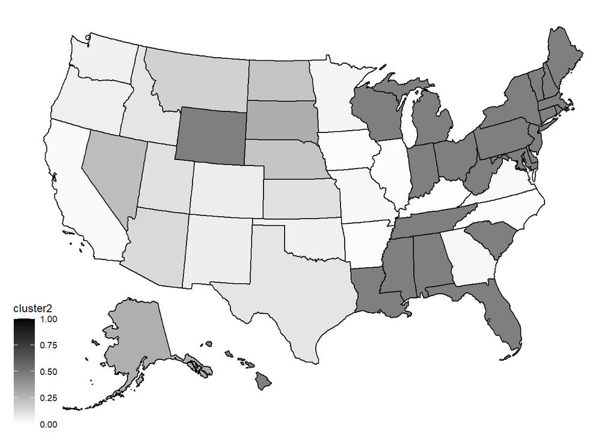

Cluster 2: Clustered counties with high access to groceries and lowest fitness establishments, mainly.

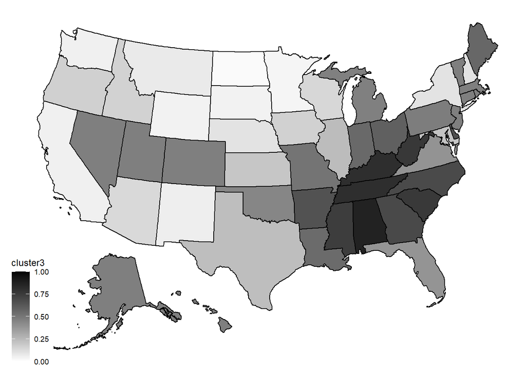

Cluster 3: Clustered counties with lowest rates of income, highest rates of diabetes and lowest rate of access to groceries.

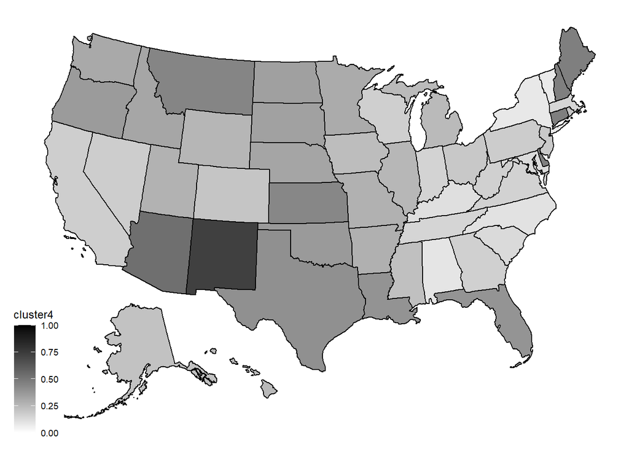

Cluster 4: Seems to have the most balance of all clusters.

## Evaluation of our Models

#### Cluster 1 Evaluation

```
##               %IncMSE IncNodePurity
## loaccgro 0.0002616216     0.1420106
## fasfoo   0.0019643544     0.2606380
## diab     0.0055175303     0.4533984
## fitplace 0.0006342932     0.1598106
## medinc   0.0012446579     0.2191012
```

Diabetes was the most important in predicting the obesity rate which makes sense since these would appear to be highly correlated variables at first glance.

Random Forest MSE:

```
## [1] 0.006136722
```

MSE using obesity rate’s mean as prediction:

```
## [1] 0.01350612
```

#### Cluster 2 Evaluation

Cluster 2 has very few data points. Because of this I will use 85% of the data as training data and tuning and the rest will be used for testing.

This was a very interesting cluster as it was supposed to concentrate counties with a really high degree of the population with access to groceries and counties with low access to gyms. Initially I believed these features wouldn’t be correlated negatively, but it seems they are, at least in the national level.

```
##           %IncMSE IncNodePurity
## loaccgro 0.000569    0.14883766
## fasfoo   0.001219    0.21474863
## diab     0.002749    0.37094615
## fitplace 0.000086    0.01696633
## medinc   0.001287    0.25967360
```

Random Forest MSE:

```
## [1] 0.01233427
```

MSE using obesity rate’s mean as prediction:

```
## [1] 0.01798417
```

The mean squared error of the sample was really low. This is to be expected, since we clustered data into four groups that are similar in determining aspects to obesity rate.

Given there’s such few data points, especially for the testing portion of this, I believe that this is a good result.

Non-surprisingly, the rate of people with diabetes in the county was the most important predictor followed by median income in the county. Next, the measure of fast food restaurants in the county and income basically tied as relevant measures in determining the obesity rate of the population.

#### Cluster 3 Evaluation

```
##               %IncMSE IncNodePurity
## loaccgro 0.0004148564    0.14368152
## fasfoo   0.0008994852    0.17054091
## diab     0.0041996768    0.32150511
## fitplace 0.0001376759    0.06746348
## medinc   0.0007539823    0.16368026
```

Random Forest MSE:

```
## [1] 0.007061758
```

MSE using obesity rate’s mean as prediction:

```
## [1] 0.01176137
```

#### Cluster 4 Evaluation

```
##               %IncMSE IncNodePurity
## loaccgro 1.104834e-04    0.13156826
## fasfoo   1.219760e-03    0.22510925
## diab     5.012530e-03    0.38400445
## fitplace 3.298028e-05    0.08183718
## medinc   7.854047e-04    0.22025044
```

Random Forest MSE:

```
## [1] 0.008394561
```

MSE using obesity rate’s mean as prediction:

```
## [1] 0.01205747
```

## Conclusions

Based on each of our random forest models, rate of diabetes in a county was clearly the best predictor of obesity rate as expected. After diabetes, the number of fast-food restaurants per 1000 people in each county was the next best predictor, ranking 2nd in variable importance for each cluster except the second. For the second cluster, median household income ranked 2nd while the number of fast food locations followed in 3rd.

Meanwhile, for every cluster except cluster 1, the number of recreation/fitness centers per 1000 people was the least useful in predicting obesity rate, while the percent of access to grocery stores ranked last in cluster 1.

In conclusion, looking at factors that may contribute to someone becoming obese (i.e. fast-food restaurants) are likely to be a better indicator than factors that would help prevent someone from becoming obese (i.e. fitness center).

## Future Work

Having more additional factors would have been beneficial to look into considering we only had 5 features. Our features were also more on the obvious side of predicting obesity, considering the outcomes weren’t all too surprising. Including variables such as population demographics (i.e. age, ethnicity, etc.), population density, screen time (i.e. iPhone screen time), number of registered vehicles per household, and public transportation budget could be interesting to look into.

Furthermore, we could split our initial data set up into different ways. For instance, we could include more or less clusters. Or we could intentionally cluster certain counties together to make up specific subgroups such as organizing by state, region, time zone, etc.